# Efecto Airbnb en Barcelona

Este informe se ha generado automáticamente con R a partir del [script de Rmarkdown](https://github.com/montera34/airbn.barcelona/tree/master/analisis/montera34/preanalisis-airbnb.Rmd) disponible en el [repositorio airbnb.barcelona](https://github.com/montera34/airbn.barcelona).

## Datos

- InsideAirbnb.com/barcelona
- Fecha scraping: 2018-09-11

## Resumen

En **Barcelona** hay publicados 19.200 anuncios de Airbnb, que tienen capacidad para 63.652 plazas (accommodates).

De esos anuncios 9.168 tienen rellena la parte de la licencia (lo que supone un 47.8 % del municipio).

Estos anuncios (listings, en la terminología de Airbnb) han sido publicados por 10.056 anfitriones.

## Anfitriones en Airbnb

### Los anfitriones con más alojamientos

| host_id | host_name | alojamientos | plazas |
| --- | --- | --- | --- |
| 4459553 | Eva&Jacques | 192 | 1063 |
| 102947901 | Claudia | 120 | 627 |
| 1391607 | Aline | 103 | 478 |
| 170716140 | Robbie & Kay | 97 | 410 |
| 396363 | Oscar And Diego | 94 | 559 |
| 158023606 | Sito, Habitat Apartments | 91 | 479 |
| 1503151 | Laia | 84 | 100 |
| 10704 | Weflating | 82 | 375 |
| 299462 | Enrique | 77 | 418 |
| 5878688 | Yaiza | 60 | 304 |
| 128959838 | Jordi | 59 | 413 |
| 6099660 | Barcelona Bedroom | 52 | 231 |
| 1447144 | Jaesse | 51 | 379 |
| 4085156 | Ferran | 50 | 281 |
| 170513081 | Georgina | 50 | 173 |
| 10287576 | Barcelona Nextdoor | 47 | 231 |
| 10547296 | María & Oscar | 47 | 190 |
| 32037490 | SweetInn | 45 | 232 |
| 9784103 | Marisa | 43 | 178 |
| 134698146 | Luis | 43 | 247 |
| 7843388 | Andrea | 42 | 174 |
| 86551441 | Maria Soledad | 42 | 181 |
| 2262273 | Emilia | 41 | 195 |
| 10380563 | Tendency | 41 | 205 |
| 39328627 | EnjoyBCN | 41 | 304 |

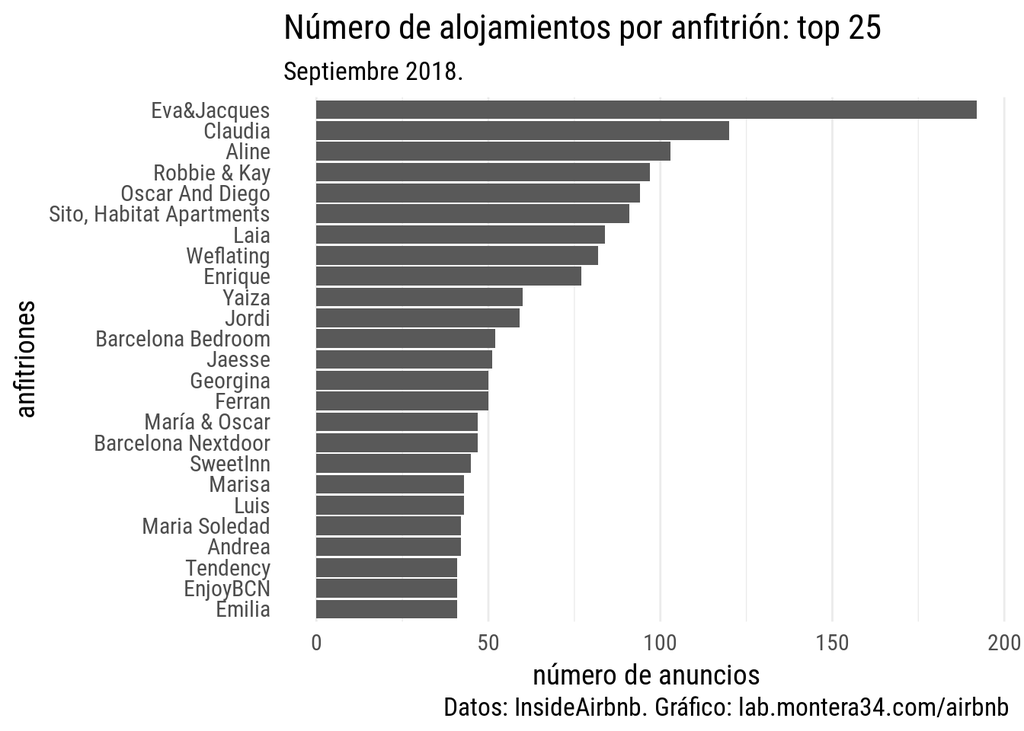

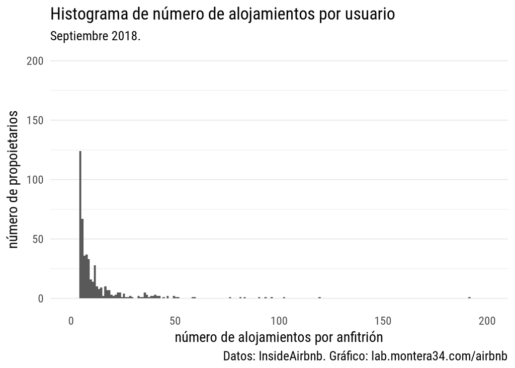

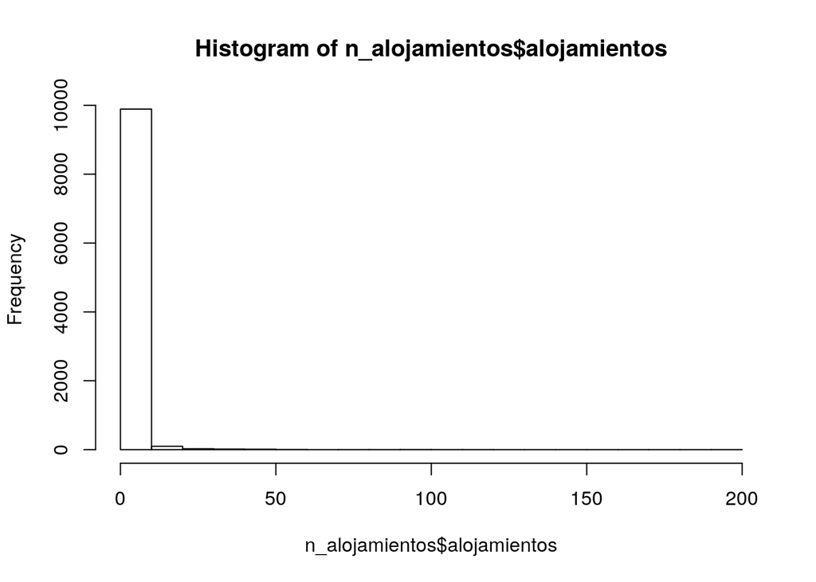

### Los anfitriones con más plazas

Los 30 anfitriones con más plazas

| host_id | host_name | plazas | alojamientos |
| --- | --- | --- | --- |
| 4459553 | Eva&Jacques | 1063 | 192 |
| 102947901 | Claudia | 627 | 120 |
| 396363 | Oscar And Diego | 559 | 94 |
| 158023606 | Sito, Habitat Apartments | 479 | 91 |
| 1391607 | Aline | 478 | 103 |
| 299462 | Enrique | 418 | 77 |
| 128959838 | Jordi | 413 | 59 |
| 170716140 | Robbie & Kay | 410 | 97 |
| 1447144 | Jaesse | 379 | 51 |
| 10704 | Weflating | 375 | 82 |
| 5878688 | Yaiza | 304 | 60 |
| 39328627 | EnjoyBCN | 304 | 41 |
| 32727836 | Sunny | 291 | 23 |
| 4085156 | Ferran | 281 | 50 |
| 134698146 | Luis | 247 | 43 |
| 157250994 | Apartment Barcino | 240 | 36 |
| 5729069 | Rosa | 239 | 26 |
| 171236207 | Apartments | 236 | 35 |
| 32037490 | SweetInn | 232 | 45 |
| 6099660 | Barcelona Bedroom | 231 | 52 |
| 10287576 | Barcelona Nextdoor | 231 | 47 |
| 1432835 | Angel | 224 | 40 |
| 8130906 | Arina | 219 | 37 |
| 2439400 | Guillermo | 215 | 36 |
| 10380563 | Tendency | 205 | 41 |
| 3376710 | Maria StayBarcelona | 199 | 40 |
| 136853 | Fidelio | 195 | 29 |
| 2262273 | Emilia | 195 | 41 |
| 10547296 | María & Oscar | 190 | 47 |
| 2320210 | Kim | 189 | 36 |

[figure not shown]

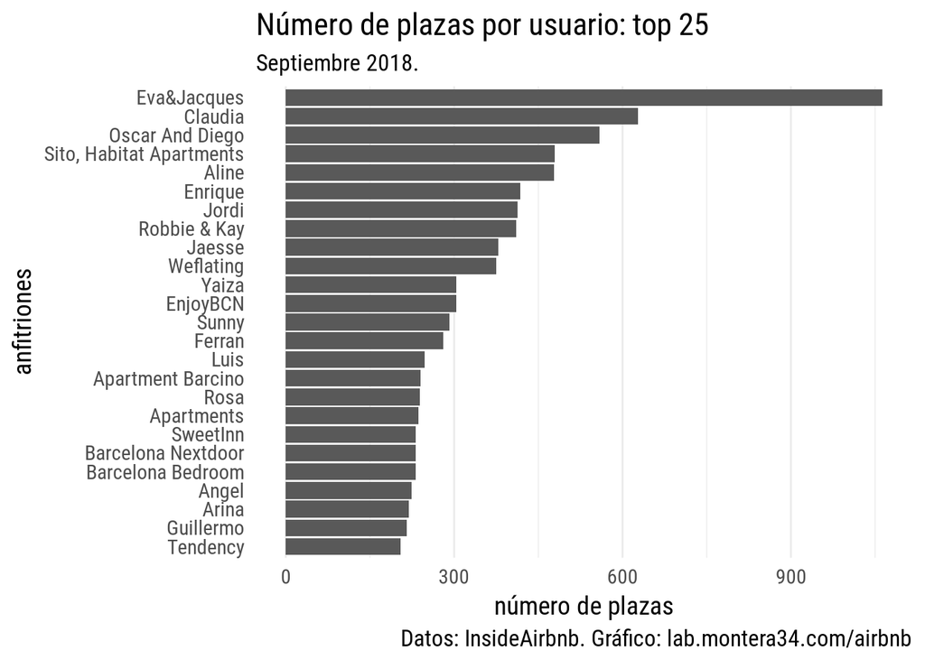

### Distribución de número de plazas por anfitriones

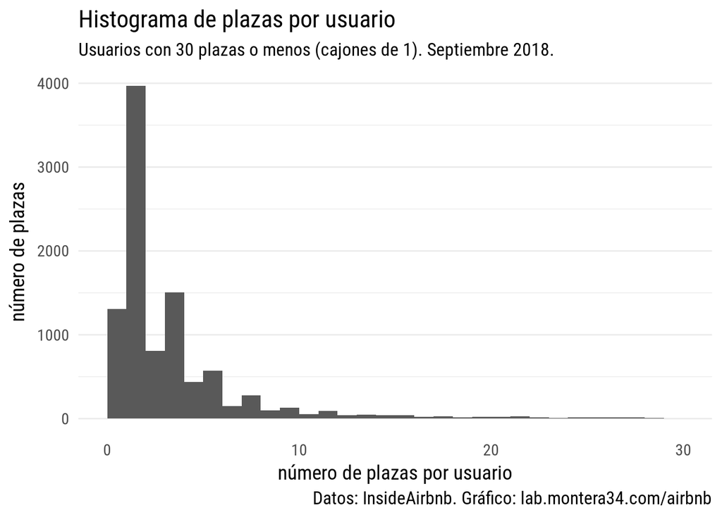

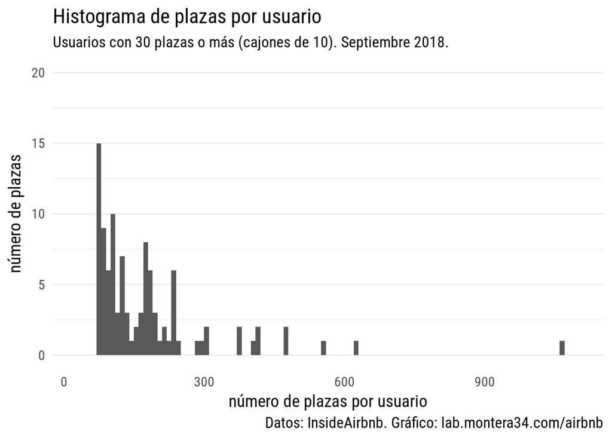

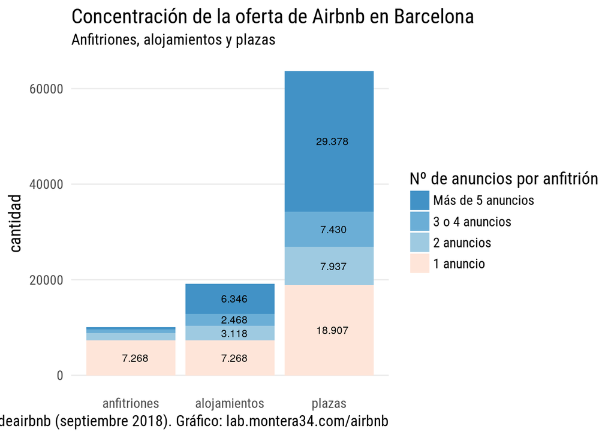

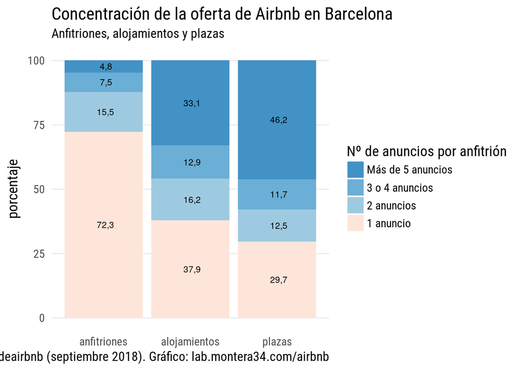

### Resumen

Los 10 primeros anfitriones (0.1% del total de anfitriones) con más plazas tienen 5201 plazas disponibles (que son el 8.2% del total de plazas).

Los 20 primeros anfitriones (0.2% del total de anfitriones) con más plazas tienen 7806 plazas disponibles (que son el 12.3% del total de plazas).

Los 50 primeros anfitriones (0.5% del total de anfitriones) con más plazas tienen 13239 plazas disponibles (que son el 20.8% del total de plazas).

Los 100 primeros anfitriones (1.0% del total de anfitriones) con más plazas tienen 18046 plazas disponibles (que son el 28.4% del total de plazas).

Los 200 primeros anfitriones (2.0% del total de anfitriones) con más plazas tienen 23445 plazas disponibles (que son el 36.8% del total de plazas).

Los 300 primeros anfitriones (3.0% del total de anfitriones) con más plazas tienen 26753 plazas disponibles (que son el 42.0% del total de plazas).

Los 500 primeros anfitriones (5.0% del total de anfitriones) con más plazas tienen 30932 plazas disponibles (que son el 48.6% del total de plazas).

## Licencias

De los 19200 hay anuncios 9168 que tienen rellena la parte de la licencia (lo que supone un 47.8 % del municipio).

Estas son las licencias más repetidas:

| license | alojamientos |
| --- | --- |
|  | 10032 |
| Exempt | 3319 |
| HUTB-123456 | 25 |
| HB-205592 | 23 |
| HB-004688 | 18 |
| HB-004666 | 17 |
| B66448176 | 14 |
| HB-004327 | 14 |
| HB-004584 | 14 |
| AJ000537 | 11 |
| Estancia larga | 11 |
| AJ000667 | 9 |
| HB-004687 | 9 |
| AJ-000588 | 8 |
| HUTB-012880 | 8 |
| HB-004527 | 7 |
| HUTB-003874 | 7 |
| HUTB-434422 | 7 |
| 0 | 6 |
| B-66578105 | 6 |